# Informe Encuesta Metodología y Técnicas Cuantitativas - 4 Análisis de textos

## 4.1 Insumos de la encuesta

El insumo de estos análisis es una serie de preguntas de respuesta abierta. Sin embargo, dado el formato específico de la pregunta se trata de un dato que, si bien no puede considerarse estructurado, se aleja un poco de otros ejemplos de datos no estructurados como los textos provenientes de entrevistas en profundidad, de canciones o de discursos presidenciales.

[figure not shown]

En este caso, como puede observarse en la imagen se trata de 3 palabras por cada encuestado. Expresado en el léxico de una matriz de datos (o base de casos x variables), se trata de 3 columnas por cada fila.

## 4.2 Preparación de los datos

Para facilitar el siguiente análisis lo que primero debemos realizar es un “alargamiento” de la base de datos original para pasar a tener una sola columna y más filas que, en principio, se repetirían 3 veces.

## 4.3 Primeras aproximaciones

Dado que los pasos anteriores nos permitieron estructurar bastante los datos, ahora es más fácil realizar los típicos análisis que se realizan a los datos estructurados. Para comenzar vamos a realizar una simple tabla de conteo, con su respectivo porcentaje, y luego vamos a realizar un gráfico de barras. Finalmente realizaremos una nube de palabras.

Frecuencia y porcentajes de palabras

| Palabra | Cantidad | Porcentaje |
| --- | --- | --- |
| investigación | 58 | 19.21% |
| encuesta | 34 | 11.26% |
| método | 31 | 10.26% |
| estadística | 26 | 8.61% |
| numeros | 22 | 7.28% |
| datos | 14 | 4.64% |
| cantidad | 13 | 4.30% |
| conocimiento | 10 | 3.31% |
| porcentaje | 9 | 2.98% |
| técnica | 8 | 2.65% |
| análisis | 6 | 1.99% |
| contar | 5 | 1.66% |
| herramientas | 5 | 1.66% |
| camino | 4 | 1.32% |
| científico | 4 | 1.32% |
| difícil | 4 | 1.32% |
| investigar | 4 | 1.32% |
| proyecto | 4 | 1.32% |
| conocer | 3 | 0.99% |
| información | 3 | 0.99% |
| medición | 3 | 0.99% |
| modos | 3 | 0.99% |
| objetivos | 3 | 0.99% |
| practica | 3 | 0.99% |
| procedimiento | 3 | 0.99% |
| proyectos | 3 | 0.99% |
| trabajosamente | 3 | 0.99% |
| cifras | 2 | 0.66% |
| cuestionarios | 2 | 0.66% |
| estudios | 2 | 0.66% |
| personas | 2 | 0.66% |
| planificación | 2 | 0.66% |
| pregunta | 2 | 0.66% |
| promedios | 2 | 0.66% |

Como en muchas otras situaciones, lo que se puede mostrar en forma de tabla también se puede graficar con algún tipo de gráfico. En este caso haremos un gráfico de barras con los datos anteriores.

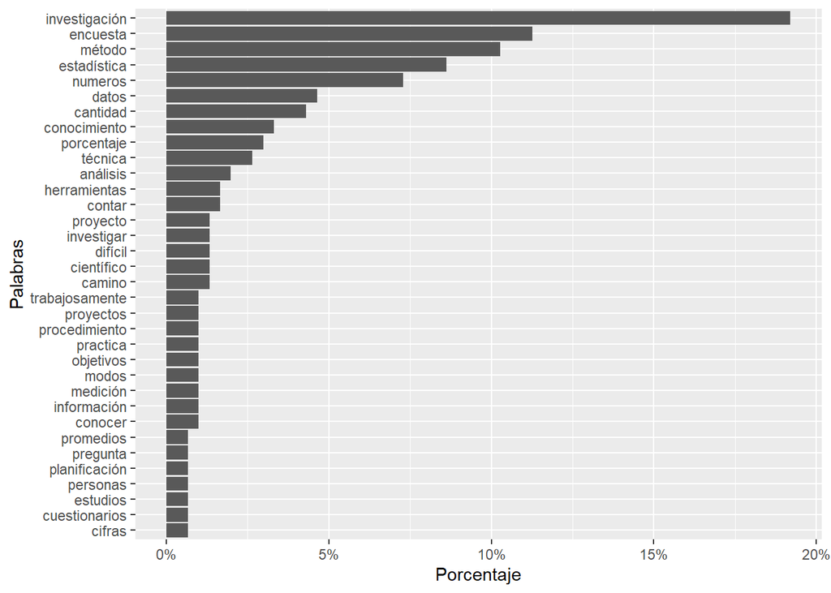

## 4.4 Nube de palabras

La nube de palabras es una técnica de visualización que funciona bien cuando los insumos son palabras y estan presentan una gran heterogeneidad en los valores de sus frecuencias.

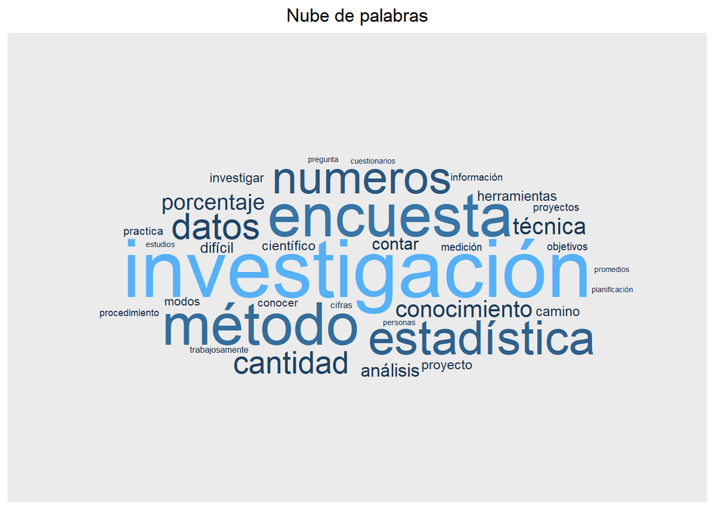

## 4.5 Análisis bivariado de palabras

Frecuencia y porcentajes de palabras según cantidad de materias aprobadas

| Palabra | Cantidad de materias aprobadas Hasta 15 | Cantidad de materias aprobadas Más de 15 |
| --- | --- | --- |
| investigación | 20.00% | 20.00% |
| encuesta | 12.22% | 10.48% |
| método | 11.11% | 10.48% |
| estadística | 7.78% | 11.43% |
| numeros | 7.78% | 6.67% |
| cantidad | 4.44% | 4.76% |
| datos | 3.33% | 7.62% |
| técnica | 3.89% | NA |
| conocimiento | 2.78% | 4.76% |
| porcentaje | 2.78% | 3.81% |
| contar | 2.22% | NA |
| investigar | 2.22% | NA |
| científico | NA | 3.81% |
| análisis | 1.67% | 2.86% |
| camino | 1.67% | NA |
| conocer | 1.67% | NA |
| difícil | 1.67% | NA |
| proyectos | 1.67% | NA |
| herramientas | 1.11% | 2.86% |
| trabajosamente | NA | 2.86% |
| información | 1.11% | NA |
| medición | 1.11% | NA |
| modos | 1.11% | NA |
| personas | 1.11% | NA |
| planificación | 1.11% | NA |
| pregunta | 1.11% | NA |
| procedimiento | 1.11% | NA |
| promedios | 1.11% | NA |
| proyecto | 1.11% | 1.90% |
| estudios | NA | 1.90% |
| objetivos | NA | 1.90% |
| practica | NA | 1.90% |

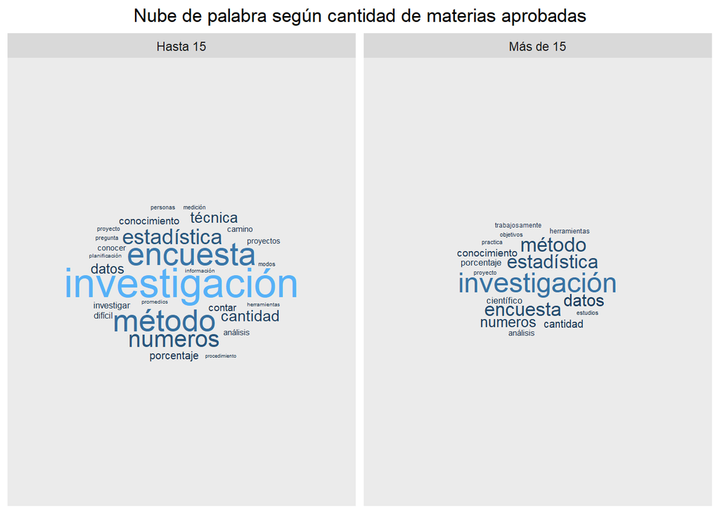